# Reading Comprehension

### Background

“This study investigated the effectiveness of explicit instruction in ‘think aloud’ as a means to promote elementary students’ comprehension monitoring abilities” [(Baumann & Jones, 1992)](http://jlr.sagepub.com/content/24/2/143.full.pdf).

### Question and Hypothesis

Given the data and having interest in teaching, I have decided to look at the performance of the students. Whenever we are looking at testing individual’s performance, we wand to maximize the potential of those individuals. The question used for this analysis is, Which method provides the best results for comprehension? In order to address this question I chose to use the third post test as my measuring point. The third test is the Degrees of Reading Power (DRP) (1986) is a standardized, commercially produced instrument that employs a modified cloze format (words are deleted from a selection and for each omission the student selects the most appropriate word from a list of five). According to the authors, DRP tests “are holistic measures of how well the messages within text are understood. . . . DRP tests focus measurement on determining how well students process or construct meaning from paragraphs as they read through a selection” (DRP Handbook, 1986, p. 1). Thus, the DRP, at one level, is a general reading comprehension assessment tool.

The null hypothesis is that all groups are samples from the same distribution. The alternative hypothesis is that one of the groups will be a sample from a different distribution.

Alpha, or the level of significance, for this test is 0.05.

### Data

The data that follows shows the experiment and the tests that were administered.

##### The DataSet

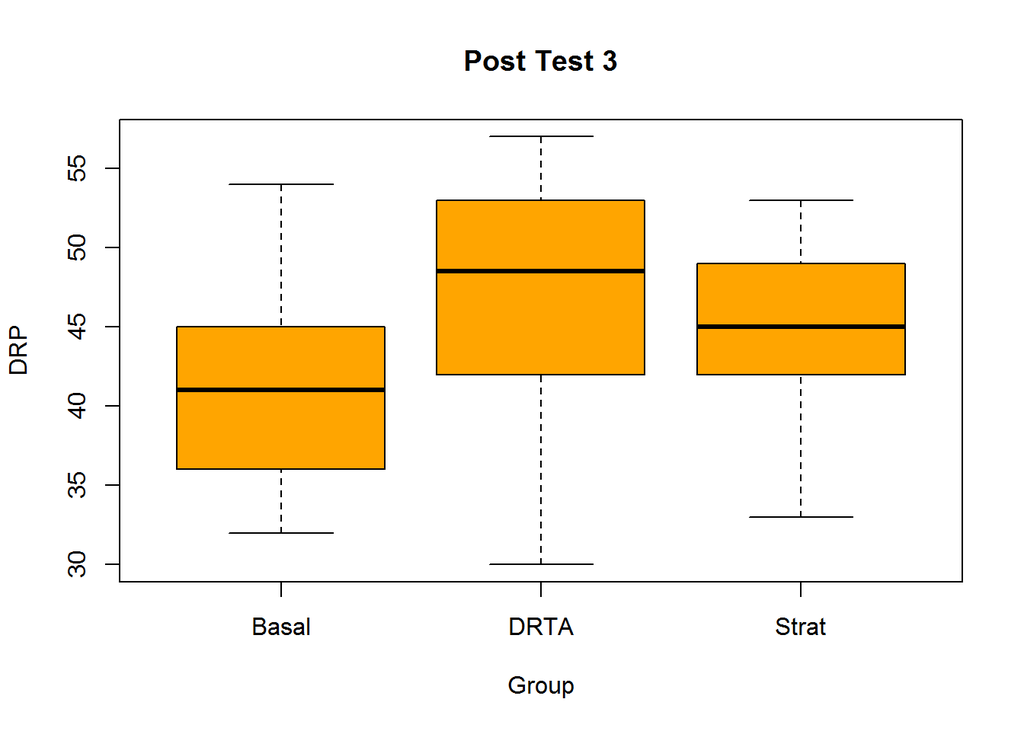

```r
boxplot(post.test.3 ~ group, data=Baumann, type=c("p","a"), col='orange', xlab="Group", ylab="DRP", main="Post Test 3")
```

```r
pander(favstats(post.test.3 ~ group, data=Baumann))
```

| group | min | Q1 | median | Q3 | max | mean | sd | n | missing |
| --- | --- | --- | --- | --- | --- | --- | --- | --- | --- |
| Basal | 32 | 36.75 | 41 | 45 | 54 | 41.05 | 5.636 | 22 | 0 |
| DRTA | 30 | 42.25 | 48.5 | 52.25 | 57 | 46.73 | 7.388 | 22 | 0 |
| Strat | 33 | 42 | 45 | 48.75 | 53 | 44.27 | 5.767 | 22 | 0 |

With this data I went forward and performed a Kruskal-Wallis Rank Sum Test based on the observations of the third post test, measuring the DRP. The groups given are Basal, which is the control, and then the two alternative styles DRTA and Strat.

```r
pander(kruskal.test(post.test.3 ~ group, data=Baumann))
```

Kruskal-Wallis rank sum test: `post.test.3` by `group`

| Test statistic | df | P value |
| --- | --- | --- |
| 9.632 | 2 | 0.0081 * * |

The Kruskal-Wallis test that was run was able to show a lot of valuable information. The chi-squared test statistic of the Kruskal-Wallis test is 9.632. Given the fact that we have three different groups, we have two degrees of freedom. Lastly, the obtained p-value is 0.0081 which gives us sufficient evidence to make an assumption.

### Interpretation

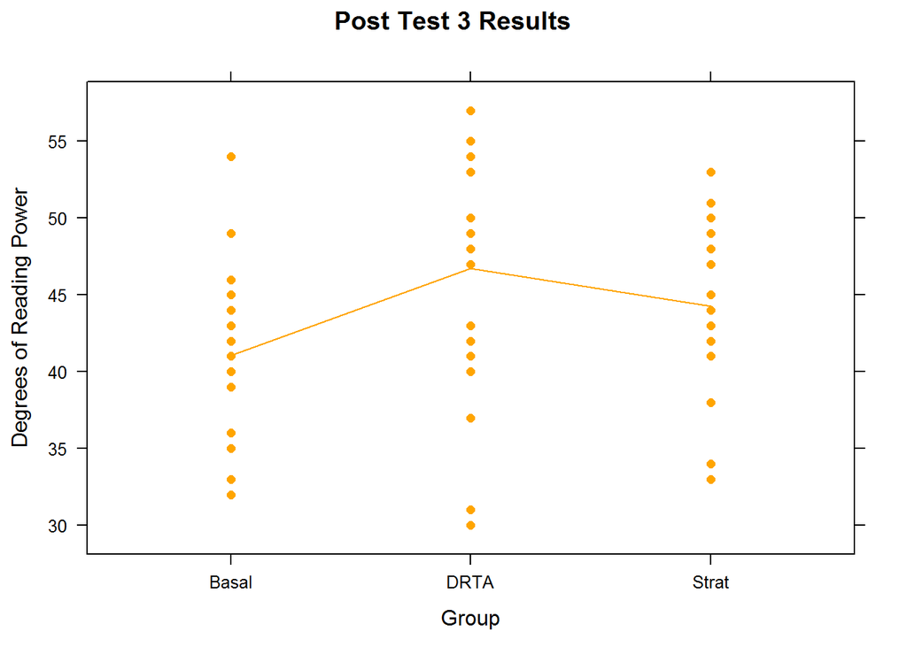

```r
xyplot(post.test.3 ~ group, data=Baumann, pch=16, col='orange', vertical=TRUE, xlab="Group", ylab="Degrees of Reading Power", main="Post Test 3 Results", type=c("p","a"))
```

I think that it would be interesting to do this experiment again but with larger numbers. Acknowledging the fact that we all have different of methods of learning, some exceptions might come with small groups like this.